# Análise de Dados de Transcriptômica Espacial

## Passos da análise de dados de transcriptômica de alta resolução

### Preparo da matriz de counts

#### Space ranger: Visium

[figure not shown]

## Volume de dados

Bulk RNA-seq

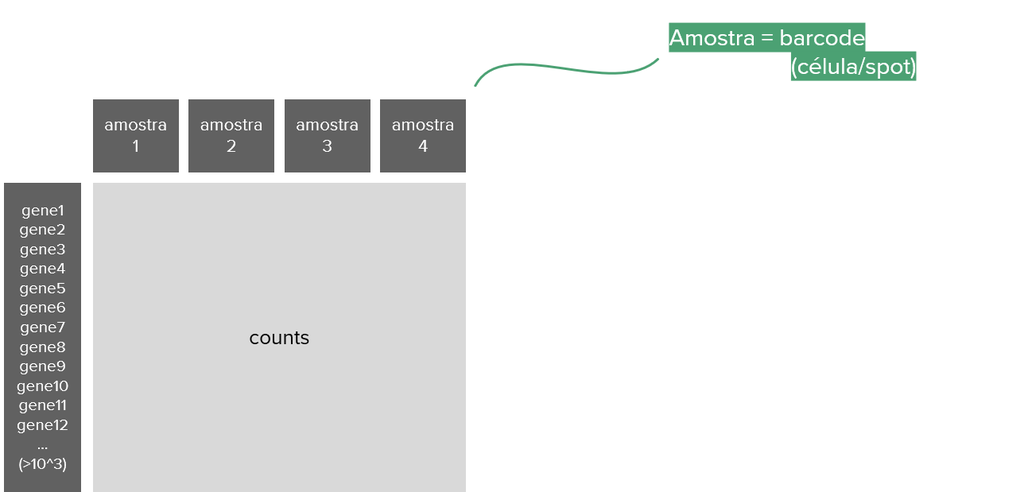

single-cell ou RNA-seq espacial

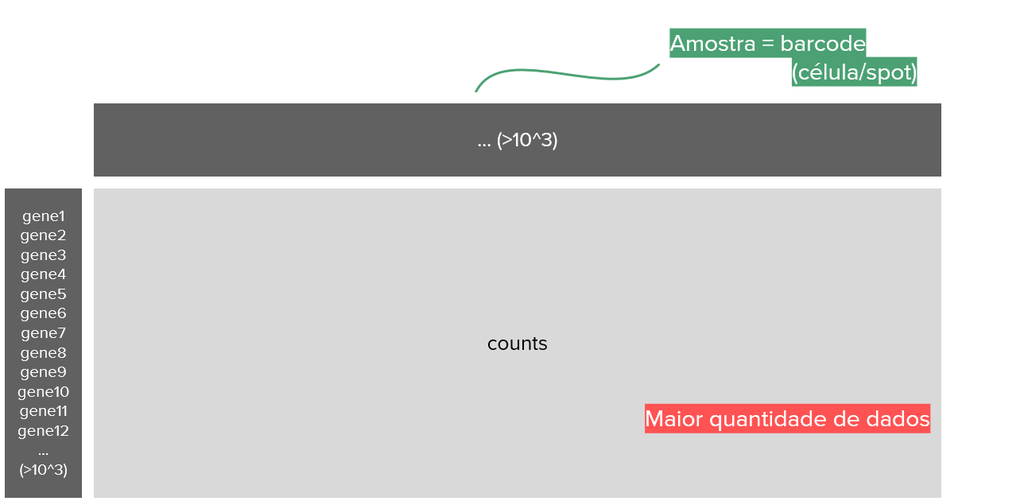

## Complexidade de dados

Matrizes muito esparsas

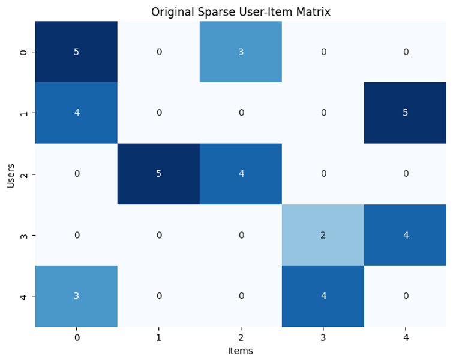

Amostras mais heterogêneas

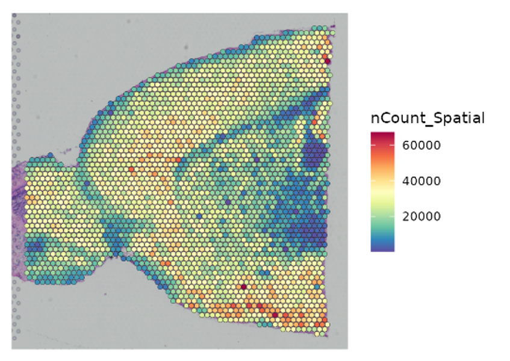

## Passos da análise de dados de transcriptômica de alta resolução

### Enfoque do curso:

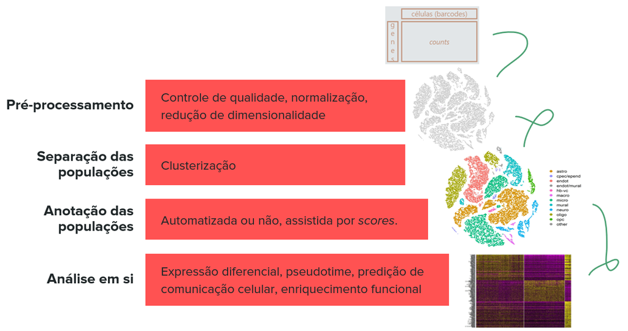

# Workflows de análise de dados de transcriptômica espacial

## Workflows de análise de dados

### Em R

#### Bioconductor

- OSTA

[figure not shown]

- Objeto SpatialExperiment

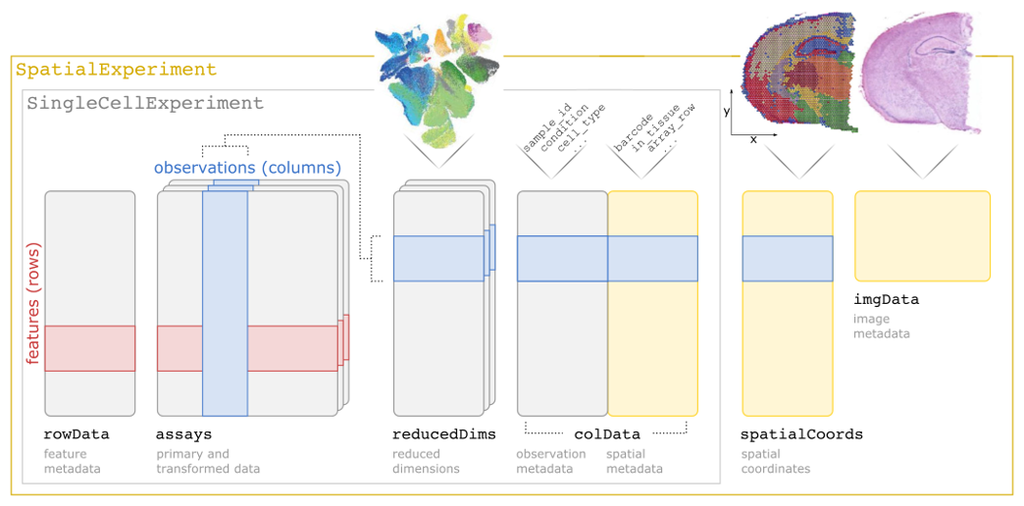

## Workflows de análise de dados

### Em R

#### Seurat V5

[figure not shown]

## Workflows de análise de dados

### Em Python (não utilizaremos no curso)

SpatialData - scverse

[figure not shown]

Squidpy

[figure not shown]

# Preparação do ambiente para análise

## Visão geral

Esta é a vinheta inicial do curso **Análise de Dados de Transcriptômica Single-Cell e Espacial**. Seu objetivo é preparar o ambiente do RStudio e instalar previamente os pacotes que serão utilizados nas aulas.

Os pacotes são organizados conforme sua origem — CRAN, Bioconductor ou GitHub — e cada instalação somente é executada quando o pacote ainda não está disponível ou não atende à versão mínima necessária. As dependências transitivas são resolvidas pelos próprios instaladores. Dessa forma, você pode executar novamente os blocos sem reinstalar desnecessariamente os pacotes que já possui.

Caso você não possua a maioria desses pacotes instalados, o processo todo pode demorar algum tempo. Por favor, mantenha atenção às mensagens de erro para evitar que algum pacote não tenha sido apropriadamente instalado.

> **Recomendação:** execute o RStudio com permissões suficientes para gravar na biblioteca de pacotes. Após concluir todas as instalações, reinicie a sessão do R antes de continuar o curso.

# Interagir com o RStudio

## Conferir o diretório de trabalho

O comando abaixo mostra o diretório de trabalho atual:

```r
getwd()
```

Se necessário, crie e defina outro diretório de trabalho. Substitua o caminho do exemplo por aquele que será utilizado no curso.

```r
# novo_diretorio <- "~/curso_transcriptomica"
# dir.create(novo_diretorio, showWarnings = FALSE, recursive = TRUE)
# setwd(novo_diretorio)
```

## Conferir os arquivos disponíveis

```r
list.files()
```

## Conferir a biblioteca de pacotes

O R procura e instala pacotes nos diretórios mostrados por:

```r
.libPaths()
```

## Instalar os pacotes do curso

Execute os próximos blocos na ordem apresentada. Dependendo da conexão com a internet e do computador utilizado, a primeira instalação pode demorar vários minutos. As versões atuais do `RGraphSpace` e do `PathwaySpace` requerem R 4.5.0 ou mais recente; o primeiro bloco interrompe a instalação com uma mensagem clara caso a versão do R precise ser atualizada.

## Pacotes do CRAN

Este bloco instala somente os pacotes do CRAN chamados diretamente pelas vinhetas ou necessários para instalar e compilar o material. O `Seurat` e o `SeuratObject` devem estar na série 5 ou mais recente.

```r
if (getRversion() < package_version("4.5.0")) {
  stop(
    "Este curso requer R 4.5.0 ou mais recente por causa do ",
    "RGraphSpace e do PathwaySpace. Atualize o R antes de continuar."
  )
}

pacotes_cran <- c(
  "Seurat", "SeuratObject", "sctransform", "dplyr", "tibble", "tidyr",
  "ggplot2", "patchwork", "gridExtra", "RANN", "future", "Matrix",
  "knitr", "rmarkdown", "remotes", "BiocManager"
)

versoes_minimas_cran <- c(
  Seurat = "5.0.0",
  SeuratObject = "5.0.0"
)

for (pacote in pacotes_cran) {
  precisa_instalar <- !requireNamespace(pacote, quietly = TRUE)

  if (
    pacote %in% names(versoes_minimas_cran) &&
    !precisa_instalar &&
    packageVersion(pacote) < package_version(versoes_minimas_cran[[pacote]])
  ) {
    precisa_instalar <- TRUE
  }

  if (precisa_instalar) {
    install.packages(pacote, dependencies = NA)
  }
}
```

## Pacotes do Bioconductor

O `BiocManager`, instalado no bloco anterior, é utilizado para obter as dependências do Bioconductor exigidas pelo `CellChat`.

```r
pacotes_bioconductor <- c("BiocGenerics", "BiocNeighbors", "ComplexHeatmap")

for (pacote in pacotes_bioconductor) {
  if (!requireNamespace(pacote, quietly = TRUE)) {
    BiocManager::install(
      pacote,
      ask = FALSE,
      update = FALSE)}}
```

## Pacotes do GitHub

Este bloco instala os pacotes obtidos diretamente do GitHub. O `SeuratData` permite acessar conjuntos de dados do Seurat; o `CellChat` é usado na inferência de comunicação celular; o `RGraphSpace` e o `PathwaySpace` sustentam as projeções espaciais; e o `spacexr` fornece a implementação do RCTD utilizada no curso.

As vinhetas internas desses pacotes não são compiladas, pois não são necessárias para o curso. Somente as dependências obrigatórias são instaladas e os demais pacotes já presentes não são atualizados em bloco. Para `RGraphSpace`, `PathwaySpace` e `spacexr`, o código também exige as versões mínimas compatíveis com este material. No caso do `spacexr`, a presença da função `create.RCTD()` é confirmada para evitar o uso acidental de uma interface incompatível.

```r
repositorios_github <- c(
  SeuratData = "satijalab/seurat-data", CellChat = "jinworks/CellChat",
  RGraphSpace = "sysbiolab/RGraphSpace", PathwaySpace = "sysbiolab/PathwaySpace",
  spacexr = "dmcable/spacexr")

versoes_minimas_github <- c(RGraphSpace = "1.5.2",PathwaySpace = "1.5.1",spacexr = "2.2.1")

for (pacote in names(repositorios_github)) {
  precisa_instalar <- !requireNamespace(pacote, quietly = TRUE)

  if (
    pacote %in% names(versoes_minimas_github) &&
    !precisa_instalar &&
    packageVersion(pacote) < package_version(versoes_minimas_github[[pacote]])
  ) {precisa_instalar <- TRUE}

  if (
    pacote == "spacexr" && !precisa_instalar &&
    !exists(
      "create.RCTD", envir = asNamespace("spacexr"),inherits = FALSE)){
    precisa_instalar <- TRUE}

  if (precisa_instalar) {
    remotes::install_github(
      repositorios_github[[pacote]],
      dependencies = NA,
      build_vignettes = FALSE,
      upgrade = "never")}}
```

## Pacote de dados do `SeuratData`

O conjunto espacial `stxBrain`, utilizado nas vinhetas de controle de qualidade e de RCTD, é distribuído como um pacote de dados separado. Para que o download não seja necessário durante as análises, o próximo bloco também o instala antecipadamente e pode demorar alguns minutos na primeira execução.

```r
pacotes_dados_seurat <- c(stxBrain.SeuratData = "stxBrain")

for (pacote in names(pacotes_dados_seurat)) {
  if (!requireNamespace(pacote, quietly = TRUE)) {
    limite_tempo_anterior <- getOption("timeout")

    tryCatch(
      {
        options(timeout = max(600, limite_tempo_anterior))
        SeuratData::InstallData(pacotes_dados_seurat[[pacote]])
      },
      finally = options(timeout = limite_tempo_anterior))}}
```

## Finalizar a configuração

Depois de executar os três grupos de instalação e instalar o conjunto de dados, reinicie a sessão pelo menu **Session > Restart R** do RStudio. Em seguida, execute o bloco abaixo para conferir a disponibilidade de todos os pacotes diretamente utilizados nas vinhetas e das dependências do Bioconductor instaladas explicitamente.

```r
pacotes_curso <- c(
  "Seurat", "SeuratObject", "SeuratData", "stxBrain.SeuratData",
  "sctransform", "dplyr", "tibble", "tidyr", "ggplot2", "patchwork",
  "gridExtra", "RANN", "future", "Matrix", "CellChat", "RGraphSpace",
  "PathwaySpace", "spacexr", "BiocGenerics", "BiocNeighbors",
  "ComplexHeatmap", "knitr", "rmarkdown", "remotes", "BiocManager"
)

estado_pacotes <- vapply(
  pacotes_curso,
  requireNamespace,
  logical(1),
  quietly = TRUE
)

data.frame(
  pacote = pacotes_curso,
  instalado = unname(estado_pacotes),
  row.names = NULL
)
```

O valor `TRUE` na coluna `instalado` confirma que o pacote correspondente está disponível. Se algum pacote aparecer como `FALSE`, execute novamente o bloco referente à sua origem e observe as mensagens apresentadas pelo R.

As versões de `Seurat`, `RGraphSpace`, `PathwaySpace` e `spacexr` são verificadas separadamente. A coluna `atende_requisito` será `TRUE` quando o pacote estiver disponível na versão mínima esperada pelo material.

```r
versoes_minimas <- c(
  Seurat = "5.0.0", RGraphSpace = "1.5.2",PathwaySpace = "1.5.1",spacexr = "2.2.1")

versoes_instaladas <- vapply(
  names(versoes_minimas),
  function(pacote) {
    if (requireNamespace(pacote, quietly = TRUE)) {
      as.character(packageVersion(pacote))
    } else {
      NA_character_
    }
  },
  character(1)
)

atende_requisito <- vapply(
  names(versoes_minimas),
  function(pacote) {
    requireNamespace(pacote, quietly = TRUE) &&
      packageVersion(pacote) >= package_version(versoes_minimas[[pacote]])
  },
  logical(1)
)

data.frame(
  pacote = names(versoes_minimas),
  versao_instalada = unname(versoes_instaladas),
  versao_minima = unname(versoes_minimas),
  atende_requisito = unname(atende_requisito),
  row.names = NULL)
```